# Unconditional and Conditional Symbolic Generation for Ragtime Music

**Penelope King, Garvey Li**

```python
import requests as re
from bs4 import BeautifulSoup
import time
import os
import sys
import math


import torch
if torch.cuda.is_available():
    device = torch.device("cuda")
    print('Using GPU (Windows)')
elif torch.backends.mps.is_available():
    device = torch.device("mps")
    print('Using GPU (Mac)')
else:
    device = torch.device("cpu")
    print('Using CPU')

from torch import nn
from torch.utils.data import Dataset, DataLoader
from torch.nn.utils.rnn import pad_sequence


from transformers import GPT2LMHeadModel, GPT2Config, Trainer, TrainingArguments

import json
from pathlib import Path
from typing import List

from miditok import REMI, TokenizerConfig, TokSequence
import miditoolkit
from miditoolkit import MidiFile, Instrument, Note
from miditok.pytorch_data import DatasetMIDI, DataCollator, DatasetJSON
from miditok.utils import split_files_for_training
from midi2audio import FluidSynth


from copy import deepcopy

from mido import MidiFile
from symusic import Score
from midiutil import MIDIFile
import pretty_midi
from pretty_midi import PrettyMIDI

from collections import Counter, defaultdict
import matplotlib.pyplot as plt
import numpy as np
from tqdm import tqdm
import pandas as pd

from glob import glob
from numpy.random import choice
from IPython.display import Audio, display
from nltk.translate.bleu_score import sentence_bleu
from sklearn.model_selection import train_test_split
```

```
Using GPU (Windows)
```

1. Tasks
2. Background
3. Data
4. Related Works
5. EDA
6. Task 1: Right Hand Unconditional Symbolic Generation
   1. Data Processing
   2. Tokenization
   3. Baseline Model
   4. GPT-2 LM Head Model
   5. Dataset
   6. Model Training
   7. Generation
   8. Evaluation
7. Task 2: Left Hand Conditional Symbolic Generation
   1. Data Processing
   2. Tokenization
   3. Baseline Model
   4. seq2seq Transformer
   5. Dataset
   6. Model Training
   7. Generation
   8. Evaluation
8. Generated Samples

## Tasks

### Task 1: Unconditional Symbolic Generation

The first task is to develop a model capable of generating a single MIDI track. More specifically, a right-hand piano melody—without any external input. The goal is to produce stylistically consistent ragtime melodies, learned from a dataset of ragtime MIDI files.

### Task 2: Conditional Symbolic Generation

The second task focuses on conditional generation. Here, the model is trained to generate a left-hand accompaniment piano track conditioned on a given right-hand ragtime piano melody. The objective is to create coherent and musically appropriate accompaniments that align with the style and rhythm of the input melody.

## Background

### What is Ragtime?

Ragtime is a music style the emrged in the late 1800s that was know for its syncopated or "ragged" rhythms. It can be thought of as a precursor to early jazz and the blues, as it had heavy influence on both genres at the time. It should be also noted that in the early days of ragtime music, much of it was not recorded and was played from memory or improvised, so the musics form tended to vary a lot between performers. Despite this, many ragtime pieces have consistent and formal structure around motifs or themes (e.g. Intro – A – A – B – B – A – C – C – D – D).

Here's an example from a well known ragtime composer:

Maple Leaf Rag - Scott Joplin

[interactive chart not shown]

## Data

The data used for model training was collected from https://www.ragtimemusic.com/, a website containing a collection of ragtime MIDI files created by Colin D. MacDonald in 1994.

```python
HEADERS = {
    "User-Agent": (
        "Mozilla/5.0 (Macintosh; Intel Mac OS X 13_4) "
        "AppleWebKit/537.36 (KHTML, like Gecko) "
        "Chrome/122.0.0.0 Safari/537.36"
    ),
    "Accept": "text/html,application/xhtml+xml,application/xml;q=0.9,image/avif,image/webp,image/apng,*/*;q=0.8",
    "Accept-Language": "en-US,en;q=0.9",
    "Accept-Encoding": "gzip, deflate, br",
    "Connection": "keep-alive",
    "Upgrade-Insecure-Requests": "1",
    "Sec-Fetch-Dest": "document",
    "Sec-Fetch-Mode": "navigate",
    "Sec-Fetch-Site": "none",
    "Sec-Fetch-User": "?1",
}
def scrape_page(url, headers=HEADERS, delay=5):
    """Retrieves content of a url if possible. Default 5 second delay between requests."""
    response = re.get(url, headers=headers)
    if response.status_code == 200:
        time.sleep(delay)
        return response
    else:
        print(f'Request unsuccessful:{response.status_code}')
        time.sleep(delay)

def get_midi_paths(url, headers=HEADERS):
    """Retrieves the paths for all MIDI file downloads"""
    base_midi_path = 'https://www.ragtimemusic.com/{x}'
    midi_paths = []
    response = scrape_page(url, headers=headers)
    soup = BeautifulSoup(response.content, 'html.parser')
    for link in soup.find_all('a'):
        link_text = link.get('href')
        if link_text and '.mid' in link_text:
            midi_paths.append(base_midi_path.format(x=link_text))
    return midi_paths


def download_midis(midi_paths, delay=5):
    """Downloads all ragtime MIDI files given a list of MIDI paths for the website."""
    print('Downloading MIDI files')
    n = len(midi_paths)
    counter = 1
    for m in midi_paths:
        print(f'{counter}/{n} files downloading')
        response = scrape_page(m, delay=delay)
        if response.status_code == 200:
            if not os.path.exists(m.split('/')[-1]):
                with open(os.path.join('..','data',m.split('/')[-1]), "wb") as f:
                    f.write(response.content)
                print("MIDI file downloaded successfully.")
            else:
                print("MIDI file already exists, skipping")
        else:
            print(f"Failed to download file: Status code {response.status_code}")
        counter += 1

def download_ragtime_midis(start_page=0, end_page=9):
    base_meta_path = 'https://www.ragtimemusic.com/title{x}.html#top%20of%20page'
    all_midi_paths = []
    print('Getting MIDI urls...')
    for i in range(start_page, end_page):
        print(f'{start_page - i}/{end_page - start_page + 1} pages...')
        all_midi_paths += get_midi_paths(base_meta_path.format(x=i))
    print('Done')
    download_midis(all_midi_paths)

if not os.path.exists('../data'):
    download_ragtime_midis()
```

## Related Works

### Pop Music Transformer (Huang & Yang, 2020)

The Pop Music Transformer (Huang & Yang, 2020) is a Transformer-XL-based model designed for generating expressive Pop piano compositions. A key contribution of this work is the introduction of REMI (REvamped MIDI), a beat-structured, event-based representation that explicitly encodes rhythmic and harmonic elements such as bars, positions, tempo, and chords. The model was trained on a dataset of 775 transcribed Pop piano performances. To evaluate rhythmic consistency and clarity, the authors used metrics like Beat STD, Downbeat STD, and Downbeat Salience. The results show that incorporating musical structure and domain knowledge through REMI leads to better generation performance than merely improving model architecture. Overall, the study highlights how structured representations can bridge the gap between symbolic music modeling and the expressive qualities of real-world Pop performance.

### A-Muze-Net: Music Generation by Composing the Harmony based on the Generated Melody (Goren et al., 2021)

A-Muze-Net: Music Generation by Composing the Harmony based on the Generated Melody (Goren et al., 2021) proposes a two-stage music generation framework using LSTM networks to separately generate the right and left hand piano tracks. The left-hand accompaniment is conditioned on the previously generated right-hand melody, using scale-invariant representations and chord-based conditioning to guide the generation. The model was trained on 243 MIDI files from the Complete Bach MIDI Index, which span diverse genres and contain two-track compositions. Evaluation metrics include QN (Qualified Notes) for measuring note duration validity, UPC (Unique Pitch Classes) for note diversity per bar, TD (Tonal Distance) for harmony-melody alignment, and OOS (Out of Scale) for the proportion of out-of-scale notes. The results show that incorporating music-theory-inspired structures such as melody-harmony hierarchy and chord conditioning enables a low-capacity LSTM model to produce musically coherent and pleasing compositions, often rivaling or outperforming more complex models.

### rag-shenanigann

Although no prior research has been conducted specifically on our dataset, past machine learning models have tackled the problem of ragtime generation. One such model is rag-shenanigann (https://github.com/s-zeng/rag-shenanigann), which uses recurrent neural networks to generate ragtime music. The model performs well in handling chords and harmony when focusing on a single track. However, consistent issues include tempo instability and stylistic inconsistency. While style inconsistency may be a fundamental limitation of neural network-based generation, tempo issues are likely due to unnormalized tempo and ticks-per-beat in the MIDI inputs. Future work should address this by standardizing tempo and ticks-per-beat across files, while ensuring the original timing and durations of the pieces are preserved.

### Our work

For Task 2 (Conditional Generation), we developed a Transformer encoder-decoder model in PyTorch to generate left-hand accompaniment conditioned on a right-hand melody. While the model was able to learn basic token patterns, the generated outputs were largely unsatisfactory. The left-hand notes were often off-beat and musically disconnected from the right-hand input, lacking the rhythmic consistency and syncopation typical of ragtime. These results suggest that while REMI tokenization provides a strong representational foundation, our current model configuration and training strategy were insufficient for learning the more complex dependencies required for conditional symbolic generation.

## EDA

### Full MIDI Data EDA

```python
def extract_midi_metadata(midi_path):
    try:
        midi = miditoolkit.midi.parser.MidiFile(midi_path)
        return {
            "file": str(midi_path),
            "filename": midi_path.name,
            "num_tracks": len(midi.instruments),
            "total_notes": sum(len(track.notes) for track in midi.instruments),
            "programs": set([inst.program for inst in midi.instruments if not inst.is_drum]),
            "tempos": midi.tempo_changes[0].tempo if midi.tempo_changes else None,
            "time_signatures": '/'.join([str(midi.time_signature_changes[0].numerator), str(midi.time_signature_changes[0].denominator)]) if midi.time_signature_changes else None,
            "key_signatures": midi.key_signature_changes[0].key_name if midi.key_signature_changes else None,
            "duration_secs": midi.max_tick / midi.ticks_per_beat
        }
    except Exception as e:
        return {
            "file": str(midi_path),
            "filename": midi_path.name,
            "error": str(e)
        }
```

```python
# Full MIDI tracks
midi_dir = Path("../data/")
midi_files = sorted(midi_dir.rglob("*.mid"))
data_path = Path("midi_metadata.csv")
if not os.path.exists(data_path):

    # Extract all metadata
    metadata = [extract_midi_metadata(path) for path in tqdm(midi_files, desc="Extracting MIDI metadata")]

    # Create DataFrame
    df = pd.DataFrame(metadata)

    df.to_csv(data_path, index=False)
else:
    df = pd.read_csv(data_path)
df
```

|  | file | filename | num_tracks | total_notes | programs | tempos | time_signatures | key_signatures | duration_secs |
| --- | --- | --- | --- | --- | --- | --- | --- | --- | --- |
| 0 | ..\data\acsrnade.mid | acsrnade.mid | 2 | 1652 | {0} | 150.000000 | 4/4 | C | 406.008333 |
| 1 | ..\data\adingysd.mid | adingysd.mid | 2 | 2353 | {0} | 80.000000 | 2/4 | Bb | 308.008333 |
| 2 | ..\data\adlyn.mid | adlyn.mid | 2 | 4650 | {0} | 89.720029 | 2/4 | D | 2678.008333 |
| 3 | ..\data\afrcnpas.mid | afrcnpas.mid | 2 | 2041 | {0} | 83.999966 | 2/4 | G | 235.008333 |
| 4 | ..\data\agitaton.mid | agitaton.mid | 2 | 2971 | {0} | 91.919932 | 2/4 | Bb | 307.941667 |
| ... | ... | ... | ... | ... | ... | ... | ... | ... | ... |
| 421 | ..\data\wwillowr.mid | wwillowr.mid | 2 | 1703 | {0} | 80.000000 | 2/4 | Eb | 235.008333 |
| 422 | ..\data\xlrag.mid | xlrag.mid | 2 | 2282 | {0} | 94.809946 | 4/8 | Db | 275.008333 |
| 423 | ..\data\yellwdog.mid | yellwdog.mid | 2 | 2124 | {0} | 151.999939 | 4/4 | D | 384.508333 |
| 424 | ..\data\ywesmile.mid | ywesmile.mid | 2 | 1742 | {0} | 86.000052 | 2/4 | F | 238.008333 |
| 425 | ..\data\ziz.mid | ziz.mid | 2 | 2705 | {0} | 120.329945 | 2/4 | Bb | 438.016667 |

426 rows × 9 columns

[figure not shown]

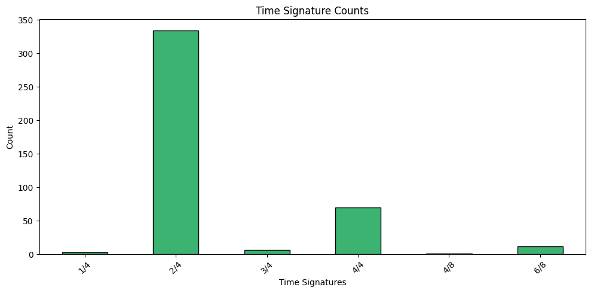

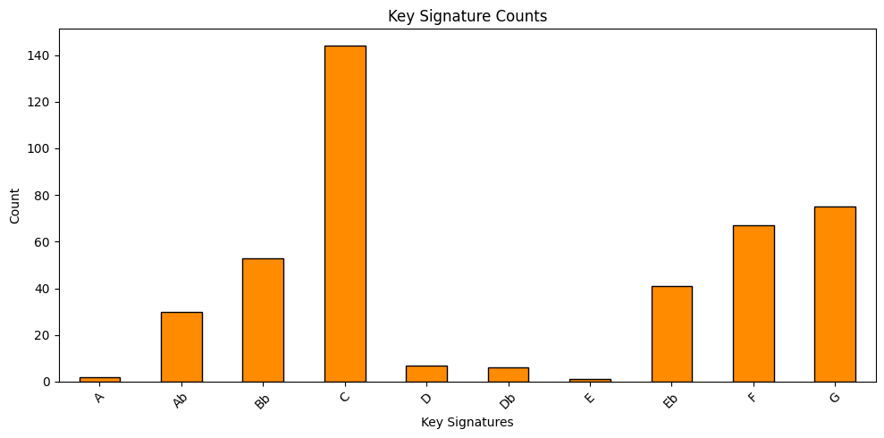

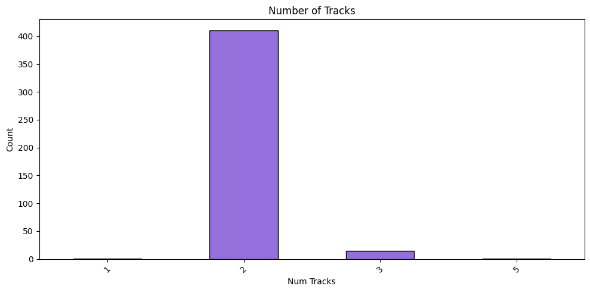

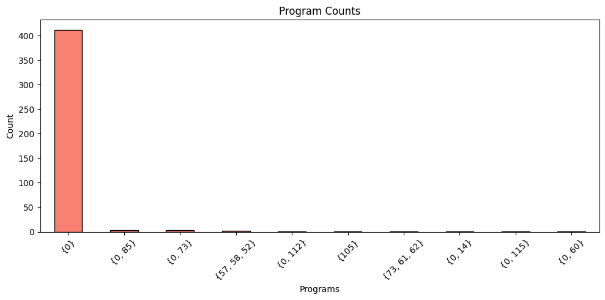

```python
def plot_histograms(df):
    fig, axes = plt.subplots(1, 3, figsize=(18, 5))

    axes[0].hist(df['total_notes'], bins=30, color='skyblue', edgecolor='black')
    axes[0].set_title('Total Notes Distribution')
    axes[0].set_xlabel('Total Notes')
    axes[0].set_ylabel('Count')

    axes[1].hist(df['tempos'], bins=30, color='lightgreen', edgecolor='black')
    axes[1].set_title('Tempos Distribution')
    axes[1].set_xlabel('Tempo (BPM)')

    axes[2].hist(df['duration_secs'], bins=30, color='salmon', edgecolor='black')
    axes[2].set_title('Duration Distribution')
    axes[2].set_xlabel('Duration (seconds)')

    plt.tight_layout()
    plt.show()

def plot_bar_counts(df, column, title, color='mediumpurple'):
    counts = df[column].value_counts().sort_index()
    plt.figure(figsize=(10, 5))
    counts.plot(kind='bar', color=color, edgecolor='black')
    plt.title(title)
    plt.xlabel(column.replace('_', ' ').title())
    plt.ylabel('Count')
    plt.xticks(rotation=45)
    plt.tight_layout()
    plt.show()

# Usage with your dataframe `df`
plot_histograms(df)
plot_bar_counts(df, 'time_signatures', 'Time Signature Counts', color='mediumseagreen')
plot_bar_counts(df, 'key_signatures', 'Key Signature Counts', color='darkorange')
plot_bar_counts(df, 'num_tracks', 'Number of Tracks', color='mediumpurple')
plot_bar_counts(df, 'programs', 'Program Counts', color='salmon')
```

Its apparent that some of the files do not meet our specifications (e.g. containing more than 2 tracks and instruments other than the Acoustic Grand Piano (program=0).

Here is a list of programs seen in the files:

- 0: Acoustic Grand Piano
- 14: Marimba
- 52: Synth Strings 1
- 57: Orchestra Hit
- 58: Trumpet
- 60: Tuba
- 61: Muted Trumpet
- 62: French Horn
- 73: Clarinet
- 85: Lead 4 (chiff)
- 105: FX 8 (sci-fi or star theme, usually an electric guitar-like pad)
- 112: Fiddle
- 115: Agogo or cowbell

All files that didn't have exactly 2 tracks also had instruments besides the Acoustic Grand Piano, so we did not process those.

```python
def extract_and_save_rh_lh(midi_path: Path, rh_out_dir: Path, lh_out_dir: Path):
    pm = pretty_midi.PrettyMIDI(str(midi_path))

    # Require exactly 2 tracks
    if len(pm.instruments) != 2:
        print(f"Skipping {midi_path.name}, does not have exactly 2 tracks.")
        return

    # Require both tracks to have program 0 and not be drums
    if any(inst.program != 0 or inst.is_drum for inst in pm.instruments):
        print(f"Skipping {midi_path.name}, contains instruments not using program 0 or are drum tracks.")
        return

    # Extract right hand (track 0)
    pm_rh = pretty_midi.PrettyMIDI()
    pm_rh.instruments.append(pm.instruments[0])

    # Extract left hand (track 1)
    pm_lh = pretty_midi.PrettyMIDI()
    pm_lh.instruments.append(pm.instruments[1])

    # Save RH MIDI
    rh_out_path = rh_out_dir / midi_path.name
    pm_rh.write(str(rh_out_path))

    # Save LH MIDI
    lh_out_path = lh_out_dir / midi_path.name
    pm_lh.write(str(lh_out_path))

    print(f"Saved RH: {rh_out_path.name} | LH: {lh_out_path.name}")



def preprocess_dataset(
    input_dir: Path,
    rh_out_dir: Path,
    lh_out_dir: Path
):
    rh_out_dir.mkdir(parents=True, exist_ok=True)
    lh_out_dir.mkdir(parents=True, exist_ok=True)

    midi_files = list(input_dir.glob("**/*.mid"))
    print(f"Found {len(midi_files)} MIDI files.")

    for midi_path in midi_files:
        try:
            extract_and_save_rh_lh(midi_path, rh_out_dir, lh_out_dir)
        except Exception as e:
            print(f"Error processing {midi_path.name}: {e}")




base_dir = Path("../data").resolve()
right_hand_dir = Path("data_right_hand").resolve()
left_hand_dir = Path("data_left_hand").resolve()

if not os.path.exists(right_hand_dir) and not os.path.exists(left_hand_dir):
    preprocess_dataset(base_dir, right_hand_dir, left_hand_dir)
    print('Splitting MIDI files...')
else:
    print('Files already split.')
```

```python
def extract_note_chord_freq(midi_path):
    """Extract note and chord frequency info from a MIDI file."""
    midi = miditoolkit.MidiFile(str(midi_path))

    notes = []
    chords = []

    # Collect notes and chords from all instruments
    for inst in midi.instruments:
        notes += [note.pitch for note in inst.notes]
        chords += [tuple(sorted([p.pitch for p in chord.notes])) for chord in getattr(inst, "chords", [])]

    note_freq = dict(Counter(notes))
    chord_freq = dict(Counter(chords))

    return note_freq, chord_freq


def extract_additional_features(midi_path):
    """Extract additional MIDI features."""
    midi = miditoolkit.MidiFile(str(midi_path))
    pm = pretty_midi.PrettyMIDI(str(midi_path))

    notes = [note for inst in midi.instruments for note in inst.notes]
    if not notes:
        return {}

    durations = [note.end - note.start for note in notes]
    velocities = [note.velocity for note in notes]
    pitches = [note.pitch for note in notes]

    pitch_classes = [p % 12 for p in pitches]
    pitch_class_counts = dict(sorted(Counter(pitch_classes).items()))

    duration_secs = pm.get_end_time()
    note_density = len(notes) / duration_secs if duration_secs > 0 else 0

    pitch_range = max(pitches) - min(pitches)
    avg_velocity = sum(velocities) / len(velocities)
    avg_duration = sum(durations) / len(durations)

    if midi.time_signature_changes:
        ts = midi.time_signature_changes[0]
        beats_per_bar = ts.numerator
        ticks_per_beat = midi.ticks_per_beat
        total_bars = midi.max_tick / (ticks_per_beat * beats_per_bar)
    else:
        total_bars = None

    data = {
        "pitch_class_histogram": pitch_class_counts,
        "note_density": note_density,
        "pitch_range": pitch_range,
        "avg_velocity": avg_velocity,
        "avg_note_duration": avg_duration,
        "total_bars": total_bars,
    }
    return data


def process_hand_midis(midi_dir: Path):
    """Process all MIDI files in a directory, extracting features into a DataFrame."""
    rows = []

    for midi_path in midi_dir.glob("*.mid"):
        note_freq, chord_freq = extract_note_chord_freq(midi_path)
        features = extract_additional_features(midi_path)

        row = {
            "filename": midi_path.name,
            "note_freq": note_freq,
            "chord_freq": chord_freq,
            **features,
        }
        rows.append(row)

    return pd.DataFrame(rows)



right_hand_dir = Path("data_right_hand")
left_hand_dir = Path("data_left_hand")

df_right = process_hand_midis(right_hand_dir)
df_left = process_hand_midis(left_hand_dir)
```

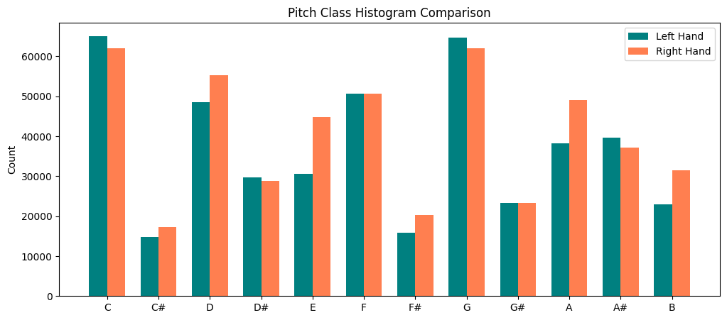

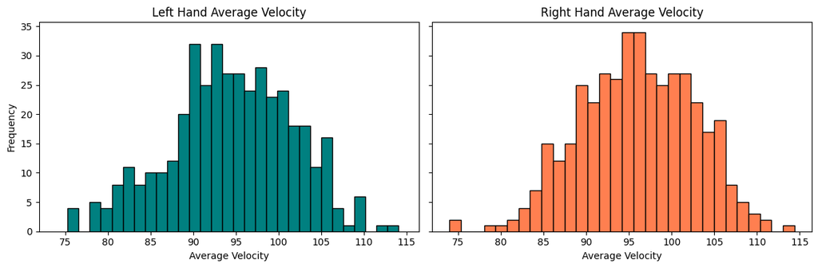

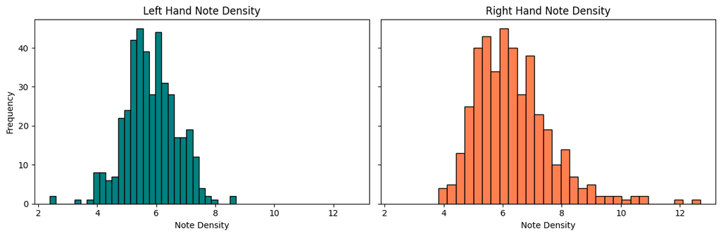

```python
def aggregate_pitch_histogram(df):
    """Aggregate pitch class histograms over all rows in the DataFrame."""
    agg_hist = Counter()
    for hist in df['pitch_class_histogram']:
        agg_hist.update(hist)
    # Convert to sorted list by pitch class 0..11
    return [agg_hist.get(i, 0) for i in range(12)]

def plot_pitch_histograms_side_by_side(df_left, df_right):
    left_hist = aggregate_pitch_histogram(df_left)
    right_hist = aggregate_pitch_histogram(df_right)

    classes = ['C', 'C#', 'D', 'D#', 'E', 'F', 'F#', 'G', 'G#', 'A', 'A#', 'B']
    x = np.arange(len(classes))
    width = 0.35

    fig, ax = plt.subplots(figsize=(12, 5), sharex=True, sharey=True)
    ax.bar(x - width/2, left_hist, width, label='Left Hand', color='teal')
    ax.bar(x + width/2, right_hist, width, label='Right Hand', color='coral')

    ax.set_xticks(x)
    ax.set_xticklabels(classes)
    ax.set_ylabel('Count')
    ax.set_title('Pitch Class Histogram Comparison')
    ax.legend()
    plt.show()

def plot_feature_histograms_side_by_side(df_left, df_right, feature, bins=30, feature_name=None):
    feature_name = feature_name or feature

    fig, axes = plt.subplots(1, 2, figsize=(12, 4), sharey=True, sharex=True)

    # Left hand plot
    axes[0].hist(df_left[feature].dropna(), bins=bins, color='teal', edgecolor='black')
    axes[0].set_title(f"Left Hand {feature_name}")
    axes[0].set_xlabel(feature_name)
    axes[0].set_ylabel("Frequency")

    # Right hand plot
    axes[1].hist(df_right[feature].dropna(), bins=bins, color='coral', edgecolor='black')
    axes[1].set_title(f"Right Hand {feature_name}")
    axes[1].set_xlabel(feature_name)

    plt.tight_layout()
    plt.show()

plot_pitch_histograms_side_by_side(df_left, df_right)

plot_feature_histograms_side_by_side(df_left, df_right, 'avg_velocity', feature_name="Average Velocity")
plot_feature_histograms_side_by_side(df_left, df_right, 'note_density', feature_name="Note Density")
```

## Task 1

### Task 1 Data Processing

1. Filter out midi files that don’t have exactly two tracks (left hand and right hand) and contain programs other than program=0 (Grand Acoustic Piano).
2. Tokenize the full MIDI files using the miditok Revamped MIDI-derived events (REMI) tokenizer (Huang & Yang, 2020) without BPE (just simple tokens to encode events like 'Pitch_55', 'Velocity_119', 'Duration_0.3.4', 'Program_0', 'Pitch_67').
3. Save the right hand tracks as their own separate MIDI files.
4. Tokenize the right hand MIDI tracks and save them to .json files
5. Load right hand .json files into a dataset, storing the token sequences as miditok TokSequences of max sequence length of 1024 and padding the shorter sequences.

### Task 1 Tokenization

Only right hand tracks are tokenized using the following parameters:

Number of velocities: Number of bins for velocity values. Reduce total vocab while keeping high level of expression

Use velocities: Include volume/expression in tokens

Use note duration programs: Adds note duration tokens

Use chords: Encodes detected chords

Use rests: Include rest tokens

Use tempos: Encodes tempo changes

Use time signatures: Encodes meter changes

No byte-pair encodings (BPE) for token substrings. Introduced too much complexity.

```python
t1_tokenizer = None
t1_tokenizer_path = Path("t1_tokenizer.json")

# Load or train tokenizer
if t1_tokenizer_path.exists():
    print('Pre-trained tokenizer exists. Loading...')
    t1_tokenizer = REMI.from_pretrained(t1_tokenizer_path)
else:
    print('No tokenizer found. Training...')

    config = TokenizerConfig(
        pitch_range=(21, 109),
        beat_res={(0, 4): 4, (4, 12): 8, (12, 32): 16},
        num_velocities=64,
        special_tokens=["PAD", "BOS", "EOS", "MASK"],
        encode_ids_split="no",
        use_velocities=True,
        use_note_duration_programs=[0],
        use_chords=True,
        use_rests=True,  # True if you want to model silences
        use_tempos=True,
        use_time_signatures=True,
        use_sustain_pedals=False,
        use_pitch_bends=False,
        use_programs=True,
        programs=[0],
        use_pitchdrum_tokens=True,
        remove_duplicated_notes=False,
        one_token_stream_for_programs=True,
    )
right_midi_dir = Path("data_right_hand")

t1_tokenizer = REMI(config)
midi_paths = list(right_midi_dir.rglob("*.mid"))
#t1_tokenizer.train(vocab_size=15000, files_paths=midi_paths)
t1_tokenizer.save(t1_tokenizer_path)

# Input and output paths
out_dir = Path("t1_tokenized_json")
out_dir.mkdir(exist_ok=True)


(right_json_dir := out_dir / "right_hand").mkdir(parents=True, exist_ok=True)

def tokenize_and_save(midi_path: Path, out_path: Path):
    tokens = t1_tokenizer.encode(midi_path)
    with open(out_path.with_suffix(".json"), "w") as f:
        #json.dump(tokens[0].ids, f)
        json.dump(tokens.ids, f)


# Tokenize right-hand tracks
print("Tokenizing right-hand MIDIs...")
for midi_file in tqdm(sorted(right_midi_dir.glob("*.mid"))):
    out_path = right_json_dir / midi_file.stem
    tokenize_and_save(midi_file, out_path)
```

```
No tokenizer found. Training...
Tokenizing right-hand MIDIs...
```

### Task 1 Baseline Model

The baseline model is a Markov Chain Trigram Model (from HW 3) that uses the REMI tokenization, extracts pitch and rhythm information from the right-hand tracks, builds n-gram models (unigram, bigram, trigram) for pitch sequences and beat patterns, and calculates transition probabilities. New music is generated by sampling notes using the trigram pitch model and sampling durations using a beat position bigram model.

```python
# midi file set up
midi_files = glob('../data/*.mid')
t1_tokenizer = REMI.from_pretrained("t1_tokenizer.json")

duration2length = {
    '0.1.8': 1,   # 32nd note (0.125 beat)
    '0.2.8': 2,   # 16th note (0.25 beat)
    '0.3.8': 3,   # Dotted 16th (0.375 beat)
    '0.4.8': 4,   # 8th note (0.5 beat)
    '0.5.8': 5,   # Equivalent to 0.625 beats (5/8 of a quarter note)
    '0.6.8': 6,   # Dotted 8th (0.75 beat)
    '0.7.8': 7,   # Approx. 0.875 beats (7/8 of a quarter note)
    '1.0.8': 8,   # Quarter note (1 beat)
    '1.2.8': 10,  # Quarter + 16th (1.25 beat)
    '1.4.8': 12,  # Dotted quarter (1.5 beat)
    '2.0.8': 16,  # Half note (2 beats)
    '3.0.8': 24,  # Dotted half (3 beats)
    '4.0.4': 32,  # Whole note (4 beats)
    '0.1.4': 2,    # 16th note (0.25 beat)
    '0.2.4': 4,    # 8th note (0.5 beat)
    '0.3.4': 6,    # Dotted 8th (0.75 beat)
    '0.4.4': 8,    # Quarter note (1 beat)
    '0.5.4': 10,   # Approx. 1.25 beats
    '0.6.4': 12,   # Approx. 1.5 beats
    '0.7.4': 14,   # Approx. 1.75 beats
    '1.0.4': 16,   # Half note (2 beats)
    '1.2.4': 20,   # Half + 16th (2.5 beats)
    '1.4.4': 24,   # Dotted half (3 beats)
}

### EXTRACTION ###

def note_extraction(midi_file):
    # Q1a: Your code goes here
    note_events = []
    midi = Score(midi_file)
    rh_track = midi.tracks[0]
    rh_score = Score()
    rh_score.tracks.append(rh_track)
    tokens = t1_tokenizer(rh_score).tokens
    for token in tokens:
        if 'Pitch' in token:
            note = int(token.split('_')[1])
            note_events.append(note)
    return note_events

def note_frequency(midi_files):
    note_counts = defaultdict(int)
    for midi_file in midi_files:
        note_events = note_extraction(midi_file)
        for note in note_events:
            note_counts[note] += 1
    return note_counts

def beat_extraction(midi_file):
    midi = Score(midi_file)
    rh_track = midi.tracks[0]
    rh_score = Score()
    rh_score.tracks.append(rh_track)
    tokens = t1_tokenizer(rh_score).tokens

    beats = []

    i = 0
    while i < len(tokens) - 4:
        if tokens[i].startswith('Position') and tokens[i+2].startswith('Pitch') and tokens[i+4].startswith('Duration'):
            position_token = tokens[i]
            duration_token = tokens[i+4]

            beat_position = int(position_token.split('_')[1])
            duration_str = duration_token.split('_')[1]
            beat_length = duration2length.get(duration_str, None)

            if beat_length is not None:
                beats.append((beat_position, beat_length))

            i += 5  # Move past the entire note event
        else:
            i += 1  # Skip malformed group

    return beats


### PROBABILITIES ###
def note_unigram_probability(midi_files):
    note_counts = note_frequency(midi_files)

    # Q2: Your code goes here
    unigramProbabilities = {}
    counts = sum(list(note_counts.values()))
    for n in note_counts:
        unigramProbabilities[n] = note_counts[n] / counts
    return unigramProbabilities

def note_bigram_probability(midi_files):
    # Q3a: Your code goes here
    bigrams = defaultdict(int)

    for file in midi_files:
        note_events = note_extraction(file)
        for (note1, note2) in zip(note_events[:-1], note_events[1:]):
            bigrams[(note1, note2)] += 1

    bigramTransitions = defaultdict(list)
    bigramTransitionProbabilities = defaultdict(list)

    for b1,b2 in bigrams:
        bigramTransitions[b1].append(b2)
        bigramTransitionProbabilities[b1].append(bigrams[(b1,b2)])

    for k in bigramTransitionProbabilities:
        Z = sum(bigramTransitionProbabilities[k])
        bigramTransitionProbabilities[k] = [x / Z for x in bigramTransitionProbabilities[k]]

    return bigramTransitions, bigramTransitionProbabilities

def note_trigram_probability(midi_files):
    # Q5a: Your code goes here
    trigrams = defaultdict(int)
    for file in midi_files:
        note_events = note_extraction(file)
        for (note1, note2, note3) in zip(note_events[:-2], note_events[1:-1], note_events[2:]):
            trigrams[(note1, note2, note3)] += 1

    trigramTransitions = defaultdict(list)
    trigramTransitionProbabilities = defaultdict(list)

    for t1,t2,t3 in trigrams:
        trigramTransitions[(t1,t2)].append(t3)
        trigramTransitionProbabilities[(t1,t2)].append(trigrams[(t1,t2,t3)])

    for k in trigramTransitionProbabilities:
        Z = sum(trigramTransitionProbabilities[k])
        trigramTransitionProbabilities[k] = [x / Z for x in trigramTransitionProbabilities[k]]

    return trigramTransitions, trigramTransitionProbabilities


def beat_pos_bigram_probability(midi_files):
    # Q8a: Your code goes here
    bigramBeatPos = defaultdict(int)
    for file in midi_files:
        beats = beat_extraction(file)
        for beat in beats:
            bigramBeatPos[(beat[0], beat[1])] += 1

    bigramBeatPosTransitions = defaultdict(list)
    bigramBeatPosTransitionProbabilities = defaultdict(list)

    for b1,b2 in bigramBeatPos:
        bigramBeatPosTransitions[b1].append(b2)
        bigramBeatPosTransitionProbabilities[b1].append(bigramBeatPos[(b1,b2)])

    for k in bigramBeatPosTransitionProbabilities:
        Z = sum(bigramBeatPosTransitionProbabilities[k])
        bigramBeatPosTransitionProbabilities[k] = [x / Z for x in bigramBeatPosTransitionProbabilities[k]]

    return bigramBeatPosTransitions, bigramBeatPosTransitionProbabilities


def beat_trigram_probability(midi_files):
    # Q9a: Your code goes here
    trigramBeat = defaultdict(int)
    for file in midi_files:
        beats = beat_extraction(file)
        for (beat1, beat2) in zip(beats[:-1], beats[1:]):
            trigramBeat[(beat1[1], beat2[0], beat2[1])] += 1

    trigramBeatTransitions = defaultdict(list)
    trigramBeatTransitionProbabilities = defaultdict(list)

    for t1,t2,t3 in trigramBeat:
        trigramBeatTransitions[(t1,t2)].append(t3)
        trigramBeatTransitionProbabilities[(t1,t2)].append(trigramBeat[(t1,t2,t3)])

    for k in trigramBeatTransitionProbabilities:
        Z = sum(trigramBeatTransitionProbabilities[k])
        trigramBeatTransitionProbabilities[k] = [x / Z for x in trigramBeatTransitionProbabilities[k]]

    return trigramBeatTransitions, trigramBeatTransitionProbabilities


### GENERATE MUSIC ###

def music_generate(length, name):
    # sample notes
    unigramProbabilities = note_unigram_probability(midi_files)
    bigramTransitions, bigramTransitionProbabilities = note_bigram_probability(midi_files)
    trigramTransitions, trigramTransitionProbabilities = note_trigram_probability(midi_files)

    # Your code goes here ...
    first_note = choice(list(unigramProbabilities.keys()), 1, p=list(unigramProbabilities.values())).item()
    second_note = choice(bigramTransitions[first_note], 1, p=bigramTransitionProbabilities[first_note]).item()
    sampled_notes = [first_note, second_note]
    while len(sampled_notes) < length:
        next_note = choice(trigramTransitions[(sampled_notes[-2], sampled_notes[-1])], 1,
                            p=trigramTransitionProbabilities[(sampled_notes[-2], sampled_notes[-1])])
        sampled_notes.append(next_note.item())

    # sample beats
    bigramBeatPosTransitions, bigramBeatPosTransitionProbabilities = beat_pos_bigram_probability(midi_files)
    first_beat = choice(bigramBeatPosTransitions[0], 1, p=bigramBeatPosTransitionProbabilities[0]).item()
    sampled_beats = [(0, first_beat)]
    while len(sampled_beats) < length:
        beat_position = sum(sampled_beats[-1]) % 32
        beat_length = choice(bigramBeatPosTransitions[beat_position], 1,
                        p=bigramBeatPosTransitionProbabilities[beat_position]).item()
        sampled_beats.append((beat_position, beat_length))
    sampled_beats = [beat[1] / 8 for beat in sampled_beats]

    # save the generated music as a midi file
    midi = MIDIFile(1)
    track = 0
    time = 0
    tempo = 60 #120
    midi.addTempo(track, time, tempo)

    current_time = 0
    for pitch, duration in zip(sampled_notes, sampled_beats):
        midi.addNote(track, 0, pitch, current_time, duration, 100)
        current_time += duration

    # Ensure directory exists
    os.makedirs("markov_model", exist_ok=True)

    # Then write the MIDI file
    with open("markov_model/{}.mid".format(name), "wb") as f:
        midi.writeFile(f)
```

```python
music_generate(100, 't1_markov')
```

### Task 1 GPT-2 Model

The GPT-2 Language Modeling Head Model takes no inputs and is trained on REMI tokenized right hand sequences using CrossEntropyLoss as the objective (it penalizes the difference between predicted token distributions and actual next tokens). Token sequences are generated by sampling from the tokens with the top 50 probabilities, which are then decoded and saved to MIDI files.

### Task 1 Dataset

```python
class MIDITokenDataset(Dataset):
    def __init__(self, files_paths, bos_token_id=None, eos_token_id=None, max_seq_len=1024):
        self.paths = files_paths
        self.bos = bos_token_id
        self.eos = eos_token_id
        self.max_seq_len = max_seq_len

    def __len__(self):
        return len(self.paths)

    def __getitem__(self, idx):
        # Load list of ids
        with open(self.paths[idx], "r") as f:
            ids = json.load(f)

        # Wrap in TokSequence (optional — just to stay consistent)
        seq = TokSequence(ids=ids)

        # Add BOS and EOS if specified
        tokens = []
        if self.bos is not None:
            tokens.append(self.bos)
        tokens += seq.ids
        if self.eos is not None:
            tokens.append(self.eos)

        # Truncate or pad as needed
        tokens = tokens[:self.max_seq_len]

        return torch.tensor(tokens)


# ----- Collate function -----
def collate_fn(batch):
    input_ids = [item["input_ids"] for item in batch]
    labels = [item["labels"] for item in batch]

    pad_token_id = t1_tokenizer["PAD_None"]
    input_ids_padded = nn.utils.rnn.pad_sequence(input_ids, batch_first=True, padding_value=pad_token_id)
    labels_padded = nn.utils.rnn.pad_sequence(labels, batch_first=True, padding_value=-100)

    return {
        "input_ids": input_ids_padded,
        "labels": labels_padded,
    }
class MIDIDataCollator:
    def __init__(self, pad_token_id):
        self.pad_token_id = pad_token_id

    def __call__(self, batch):
        # batch: list of 1D tensors
        input_ids_padded = pad_sequence(batch, batch_first=True, padding_value=self.pad_token_id)
        labels_padded = input_ids_padded.clone()  # copy for labels

        return {
            "input_ids": input_ids_padded,
            "labels": labels_padded,
            "attention_mask": (input_ids_padded != self.pad_token_id).long(),
        }



data_collator = MIDIDataCollator(t1_tokenizer['PAD_None'])
right_hand_jsons = list(Path("t1_tokenized_json/right_hand").glob("*.json"))

dataset = MIDITokenDataset(
    files_paths=right_hand_jsons,
    bos_token_id = t1_tokenizer["BOS"] if "BOS" in t1_tokenizer.special_tokens else t1_tokenizer.vocab["BOS_None"],
    eos_token_id = t1_tokenizer["EOS"] if "EOS" in t1_tokenizer.special_tokens else t1_tokenizer.vocab["EOS_None"],
    max_seq_len=512*2
)
```

### Task 1 Model Training

```python
config = GPT2Config(
    vocab_size=t1_tokenizer.vocab_size,
    n_positions=1024,
    n_layer=6,
    n_head=8,
    n_embd=512,
)
model = GPT2LMHeadModel(config)
training_args = TrainingArguments(
    output_dir="out",
    per_device_train_batch_size=4,
    num_train_epochs=1000,
    save_steps=500,
    logging_steps=100,
    warmup_steps=100,
    logging_dir="logs",
    report_to="none",  # or "tensorboard" if you use it
    save_total_limit=2,
)
trainer = Trainer(
    model=model,
    args=training_args,
    train_dataset=dataset,
    data_collator=data_collator,

)
trainer.train()
model.save_pretrained("t1_model_weights")
```

### Task 1 Generation

```python
# MIDI Generation
valid_token_ids = list(t1_tokenizer.vocab.values())  # get all integer token IDs
valid_token_ids_tensor = torch.tensor(valid_token_ids, device=device)

vocab_size = model.config.vocab_size  # 15000
mask = torch.full((vocab_size,), float('-inf'), device=device)
mask[valid_token_ids_tensor] = 0

def generate_unconditional_midi(
    model,
    tokenizer,
    output_path="generated.mid",
    max_len=512*2,
    device="cpu"
):
    model.eval()

    # Get BOS and EOS token ids correctly from tokenizer.vocab dict
    bos_token_id = tokenizer.vocab.get("BOS_None", tokenizer.vocab.get("BOS"))
    eos_token_id = tokenizer.vocab.get("EOS_None", tokenizer.vocab.get("EOS"))

    generated = [bos_token_id]
    input_ids = torch.tensor([generated], dtype=torch.long, device=device)

    with torch.no_grad():
        for _ in range(max_len):
            outputs = model(input_ids=input_ids)
            logits = outputs.logits[0, -1, :]  # (vocab_size,)

            # Apply mask to block invalid tokens
            logits = logits + mask

            #next_token_id = torch.argmax(logits).item()
            top_k = 50
            logits = logits + mask  # apply vocab mask
            top_logits, top_indices = torch.topk(logits, top_k)
            probs = torch.nn.functional.softmax(top_logits, dim=-1)
            next_token_id = top_indices[torch.multinomial(probs, num_samples=1)].item()

            if next_token_id == eos_token_id:
                break

            generated.append(next_token_id)
            # Update input_ids with newly generated tokens (avoid recreating tensor every time by slicing)
            input_ids = torch.tensor([generated], dtype=torch.long, device=device)

    print(f"Generated {len(generated)} tokens.")
    print("Tokens:", generated)
    score = tokenizer.decode(generated)  # symusic ScoreTick object
    print("Score:",score)
    score.dump_midi(output_path)         # save midi directly via symusic method
    print(f"Saved generated MIDI to {output_path}")
model = GPT2LMHeadModel.from_pretrained("t1_model_weights").to(device)
generate_unconditional_midi(
    model=model,
    tokenizer=t1_tokenizer,
    output_path="unconditional_generation.mid",
    max_len=512*2,
    device=device
)
```

### Task 1 Evaluation

```python
# ===== Helpers to get MIDI files =====

def get_midi_files_from_folder(folder_path):
    midi_files = []
    for file in os.listdir(folder_path):
        if file.lower().endswith(('.mid', '.midi')):
            midi_files.append(os.path.join(folder_path, file))
    return midi_files

# ===== Parse notes from right hand (track 0) only =====

def parse_rh_notes_pretty_midi(midi_file):
    """
    Extract notes only from first instrument (track 0) - assumed right hand.
    Returns list of (pitch, duration) tuples.
    """
    pm = pretty_midi.PrettyMIDI(midi_file)
    if len(pm.instruments) == 0:
        return []
    rh_instrument = pm.instruments[0]
    notes = []
    for note in rh_instrument.notes:
        duration = note.end - note.start
        notes.append((note.pitch, duration))
    return notes

# For model-generated samples, assume same parsing (right hand only)
parse_model_notes = parse_rh_notes_pretty_midi

# ===== Histogram computations =====

def get_pitch_histogram(notes, bins=range(21, 109)):
    pitches = [p for p, d in notes]
    hist, _ = np.histogram(pitches, bins=bins)
    hist = hist.astype(float)
    return hist / hist.sum() if hist.sum() > 0 else hist

def get_duration_histogram(notes, bins=None):
    durations = [d for p, d in notes]
    if bins is None:
        bins = np.linspace(0, 2.0, 20)  # durations up to 2 seconds
    hist, _ = np.histogram(durations, bins=bins)
    hist = hist.astype(float)
    return hist / hist.sum() if hist.sum() > 0 else hist

# ===== Aggregation for multiple files =====

def aggregate_notes_from_midis(midi_files, parser):
    all_notes = []
    for f in midi_files:
        try:
            notes = parser(f)
            all_notes.extend(notes)
        except Exception as e:
            print(f"Failed to parse {f}: {e}")
    return all_notes

# ===== Self-BLEU computation =====

def notes_to_pitch_sequence(notes):
    return [p for p, d in notes]

def self_bleu(generated_samples):
    """
    Compute average Self-BLEU for a list of generated samples (pitch sequences).
    """
    scores = []
    for i, hyp in enumerate(generated_samples):
        refs = [s for j, s in enumerate(generated_samples) if j != i]
        if len(refs) == 0:
            continue
        try:
            score = sentence_bleu(refs, hyp, weights=(0.5, 0.5))
            scores.append(score)
        except:
            # BLEU may fail if sequences are too short
            pass
    return np.mean(scores) if scores else 0.0

def get_pitch_sequences(midi_files, parser):
    sequences = []
    for f in midi_files:
        notes = parser(f)
        seq = notes_to_pitch_sequence(notes)
        if len(seq) > 0:
            sequences.append(seq)
    return sequences

# ===== Histogram plotting =====

def plot_histograms(hist1, hist2, label1='Model1', label2='Model2', title='Histogram comparison'):
    plt.figure(figsize=(10, 4))
    width = 0.4
    x = np.arange(len(hist1))
    plt.bar(x - width/2, hist1, width=width, label=label1)
    plt.bar(x + width/2, hist2, width=width, label=label2)
    plt.title(title)
    plt.xlabel('Bin Index')
    plt.ylabel('Normalized Frequency')
    plt.legend()
    plt.show()
```

```python
def get_tempo_std(midi_file):
    pm = pretty_midi.PrettyMIDI(midi_file)
    tempos, _ = pm.get_tempo_changes()
    if len(tempos) <= 1:
        return 0.0  # Only one tempo means perfectly consistent
    return np.std(tempos)

def aggregate_tempo_std(midi_files):
    tempo_stds = []
    for f in midi_files:
        try:
            std = get_tempo_std(f)
            tempo_stds.append(std)
        except Exception as e:
            print(f"Failed to process {f}: {e}")
    return np.mean(tempo_stds), np.std(tempo_stds)


def get_beat_std(midi_file):
    pm = pretty_midi.PrettyMIDI(midi_file)
    beat_times = pm.get_beats()
    if len(beat_times) < 2:
        return 0.0
    beat_intervals = np.diff(beat_times)
    return np.std(beat_intervals)

def aggregate_beat_std(midi_files):
    beat_stds = []
    for f in midi_files:
        try:
            std = get_beat_std(f)
            beat_stds.append(std)
        except Exception as e:
            print(f"Failed to process {f}: {e}")
    return np.mean(beat_stds), np.std(beat_stds)


def get_tempo_std(midi_file):
    """
    Compute the standard deviation of tempo values in a MIDI file.
    Lower values indicate more consistent tempo.
    """
    pm = pretty_midi.PrettyMIDI(midi_file)
    tempos, _ = pm.get_tempo_changes()
    if len(tempos) <= 1:
        return 0.0  # One tempo = perfectly consistent
    return np.std(tempos)

def aggregate_tempo_stds(midi_files):
    """
    Compute mean and std of Tempo STD across multiple MIDI files.
    """
    tempo_stds = []
    for f in midi_files:
        try:
            std = get_tempo_std(f)
            tempo_stds.append(std)
        except Exception as e:
            print(f"Failed to process {f}: {e}")
    if not tempo_stds:
        return 0.0, 0.0
    return np.mean(tempo_stds), np.std(tempo_stds)
```

```python
train_folder = '../data/'
model1_folder = 'markov_model/'
model2_folder = 'symbolic_unconditional/'


train_midis = get_midi_files_from_folder(train_folder)
markov_midis = get_midi_files_from_folder(model1_folder)
su_midis = get_midi_files_from_folder(model2_folder)
```

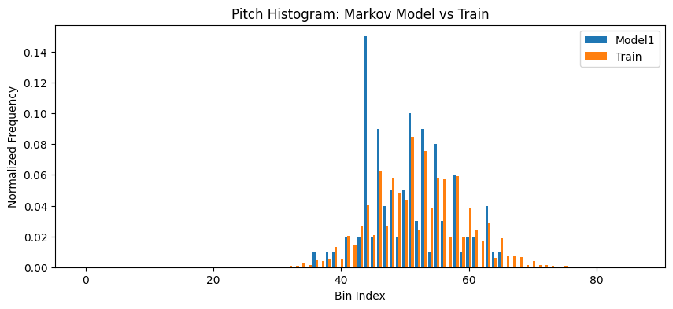

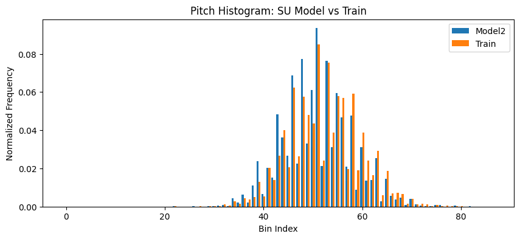

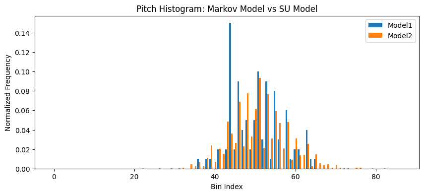

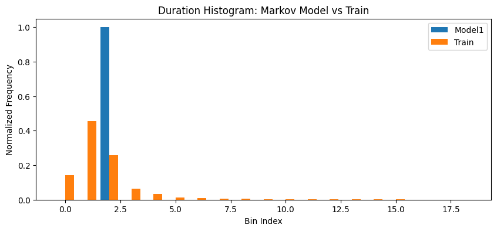

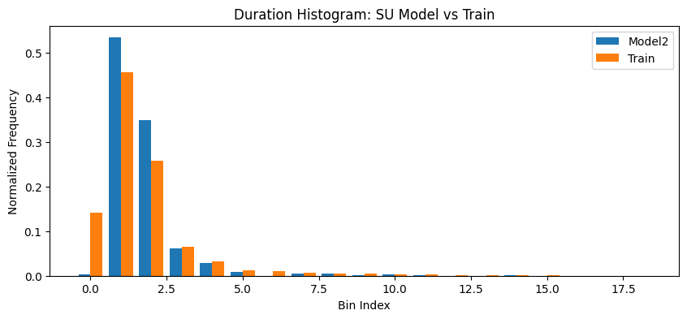

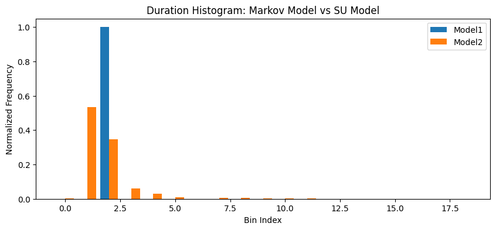

```python
# Aggregate notes (only right hand for train, right hand assumed for models)
train_notes = aggregate_notes_from_midis(train_midis, parse_rh_notes_pretty_midi)
model1_notes = aggregate_notes_from_midis(markov_midis, parse_model_notes)
model2_notes = aggregate_notes_from_midis(su_midis, parse_model_notes)

# Compute histograms
pitch_bins = range(21, 109)
duration_bins = np.linspace(0, 2.0, 20)

train_pitch_hist = get_pitch_histogram(train_notes, bins=pitch_bins)
model1_pitch_hist = get_pitch_histogram(model1_notes, bins=pitch_bins)
model2_pitch_hist = get_pitch_histogram(model2_notes, bins=pitch_bins)

train_duration_hist = get_duration_histogram(train_notes, bins=duration_bins)
model1_duration_hist = get_duration_histogram(model1_notes, bins=duration_bins)
model2_duration_hist = get_duration_histogram(model2_notes, bins=duration_bins)


# Plot pitch histograms: model vs train
plot_histograms(model1_pitch_hist, train_pitch_hist, 'Model1', 'Train', 'Pitch Histogram: Markov Model vs Train')
plot_histograms(model2_pitch_hist, train_pitch_hist, 'Model2', 'Train', 'Pitch Histogram: SU Model vs Train')

# Plot pitch histograms: model1 vs model2
plot_histograms(model1_pitch_hist, model2_pitch_hist, 'Model1', 'Model2', 'Pitch Histogram: Markov Model vs SU Model')

# Plot duration histograms similarly
plot_histograms(model1_duration_hist, train_duration_hist, 'Model1', 'Train', 'Duration Histogram: Markov Model vs Train')
plot_histograms(model2_duration_hist, train_duration_hist, 'Model2', 'Train', 'Duration Histogram: SU Model vs Train')
plot_histograms(model1_duration_hist, model2_duration_hist, 'Model1', 'Model2', 'Duration Histogram: Markov Model vs SU Model')

# Compute Self-BLEU on pitch sequences
model1_sequences = get_pitch_sequences(markov_midis, parse_model_notes)
model2_sequences = get_pitch_sequences(su_midis, parse_model_notes)

model1_self_bleu = self_bleu(model1_sequences)
model2_self_bleu = self_bleu(model2_sequences)
```

```python
train_beat_mean, train_beat_std = aggregate_beat_std(train_midis)
model1_beat_mean, model1_beat_std = aggregate_beat_std(markov_midis)
model2_beat_mean, model2_beat_std = aggregate_beat_std(su_midis)

print(f"Train Beat STD Mean: {train_beat_mean:.4f}")
print(f"Model1 Beat STD Mean: {model1_beat_mean:.4f}")
print(f"Model2 Beat STD Mean: {model2_beat_mean:.4f}")


print(f"Model1 Self-BLEU (diversity): {model1_self_bleu:.4f}")
print(f"Model2 Self-BLEU (diversity): {model2_self_bleu:.4f}")


train_tempo_mean, train_tempo_std = aggregate_tempo_stds(train_midis)
model1_tempo_mean, model1_tempo_std = aggregate_tempo_stds(markov_midis)
model2_tempo_mean, model2_tempo_std = aggregate_tempo_stds(su_midis)

print(f"Train Tempo STD Mean: {train_tempo_mean:.4f}")
print(f"Model1 Tempo STD Mean: {model1_tempo_mean:.4f}")
print(f"Model2 Tempo STD Mean: {model2_tempo_mean:.4f}")
```

```
Train Beat STD Mean: 0.0192
Model1 Beat STD Mean: 0.0000
Model2 Beat STD Mean: 0.0000
Model1 Self-BLEU (diversity): 0.9582
Model2 Self-BLEU (diversity): 0.4097
Train Tempo STD Mean: 44.4347
Model1 Tempo STD Mean: 0.0000
Model2 Tempo STD Mean: 0.0000
```

## Lower values indicate more consistent beat spacing (i.e., steadier rhythm or tempo feel).

### Notes

#### Single Model Output

Self-BLEU: diversity within generated samples

#### Compare between training data

Pitch Histogram Distance: Compare pitch distributions (e.g., histogram difference, Earth Mover’s Distance).

Duration Histogram Distance: Compare note duration distributions.

#### Compare between Models

Pitch Histogram Distance: Compare pitch distributions (e.g., histogram difference, Earth Mover’s Distance).

Duration Histogram Distance: Compare note duration distributions.

### Model Perplexity

```python
bos_token_id = t1_tokenizer["BOS"] if "BOS" in t1_tokenizer.special_tokens else t1_tokenizer.vocab["BOS_None"]
eos_token_id = t1_tokenizer["EOS"] if "EOS" in t1_tokenizer.special_tokens else t1_tokenizer.vocab["EOS_None"]

# Dataset and DataLoader
loader = DataLoader(dataset, batch_size=4, shuffle=False, collate_fn=data_collator)

def compute_perplexity(model, dataloader, device='cuda'):
    model.eval()
    model.to(device)
    total_loss = 0.0
    total_tokens = 0

    with torch.no_grad():
        for batch in dataloader:
            input_ids = batch['input_ids'].to(device)
            labels = batch['labels'].to(device)
            attention_mask = batch['attention_mask'].to(device)

            outputs = model(input_ids=input_ids, attention_mask=attention_mask, labels=labels)
            loss = outputs.loss
            # Count tokens ignoring padding:
            num_tokens = attention_mask.sum().item()

            total_loss += loss.item() * num_tokens
            total_tokens += num_tokens

    avg_loss = total_loss / total_tokens
    perplexity = math.exp(avg_loss)
    return perplexity


# Evaluate
ppl = compute_perplexity(model, loader, device=device)
print(f"Perplexity: {ppl:.2f}")
```

```
Perplexity: 1.01
```

## Task 2

### Task 2 Data Processing

1. Filter out midi files that don’t have exactly two tracks (left hand and right hand) and contain programs other than program=0 (Grand Acoustic Piano).
2. Tokenize the full MIDI files using the miditok Revamped MIDI-derived events (REMI) tokenizer (Huang & Yang, 2020) without BPE (just simple tokens to encode events like 'Pitch_55', 'Velocity_119', 'Duration_0.3.4', 'Program_0', 'Pitch_67').
3. Save the left hand and right hand tracks as their own separate MIDI files.
4. Tokenize the left and right hand MIDI tracks and save them to .json files
5. Load right hand .json files into a dataset, storing the token sequences as miditok TokSequences of max sequence length of 1024 and padding the shorter sequences.

### Task 2 Tokenization

Tokenized both right and left hand tracks using the following parameters:

Number of velocities: Number of bins for velocity values. Reduce total vocab while keeping high level of expression

Use velocities: Include volume/expression in tokens

Use note duration programs: Adds note duration tokens

Use chords: Encodes detected chords

Use rests: Include rest tokens

Use tempos: Encodes tempo changes

Use time signatures: Encodes meter changes

No byte-pair encodings (BPE) for token substrings. Introduced too much complexity.

```python
# To initialize/load
t2_tokenizer = None
t2_tokenizer_path = Path("t2_tokenizer.json")

# Load or train tokenizer
if t2_tokenizer_path.exists():
    print('Pre-trained tokenizer exists. Loading...')
    t2_tokenizer = REMI.from_pretrained(t2_tokenizer_path)
else:
    print('No tokenizer found. Training...')
    #config = t2_TokenizerConfig(num_velocities=32, use_chords=True, use_programs=True)

    config = TokenizerConfig(
        pitch_range=(21, 109),
        beat_res={(0, 4): 4, (4, 12): 8, (12, 32): 16},
        num_velocities=64,
        special_tokens=["PAD", "BOS", "EOS", "MASK"],
        encode_ids_split="no",
        use_velocities=True,
        use_note_duration_programs=[0],
        use_chords=True,
        use_rests=True,  # True if you want to model silences
        use_tempos=True,
        use_time_signatures=True,
        use_sustain_pedals=False,
        use_pitch_bends=False,
        use_programs=True,
        programs=[0],
        use_pitchdrum_tokens=True,
        remove_duplicated_notes=False,
        one_token_stream_for_programs=True,
    )

    t2_tokenizer = REMI(config)
    midi_paths = list(Path("../data").rglob("*.mid"))
    #t2_tokenizer.train(vocab_size=30000, files_paths=midi_paths)
    t2_tokenizer.save(t2_tokenizer_path)

# Input and output paths
out_dir = Path("t2_tokenized_json")
out_dir.mkdir(exist_ok=True)

right_midi_dir = Path("data_right_hand")
left_midi_dir = Path("data_left_hand")

(right_json_dir := out_dir / "right_hand").mkdir(parents=True, exist_ok=True)
(left_json_dir := out_dir / "left_hand").mkdir(parents=True, exist_ok=True)

def tokenize_and_save(midi_path: Path, out_path: Path):
    tokens = t2_tokenizer.encode(midi_path)
    with open(out_path.with_suffix(".json"), "w") as f:
        json.dump(tokens.ids, f)


# Tokenize right-hand tracks
print("Tokenizing right-hand MIDIs...")
for midi_file in tqdm(sorted(right_midi_dir.glob("*.mid"))):
    out_path = right_json_dir / midi_file.stem
    tokenize_and_save(midi_file, out_path)

# Tokenize left-hand tracks
print("Tokenizing left-hand MIDIs...")
for midi_file in tqdm(sorted(left_midi_dir.glob("*.mid"))):
    out_path = left_json_dir / midi_file.stem
    tokenize_and_save(midi_file, out_path)
```

```
No tokenizer found. Training...
Tokenizing right-hand MIDIs...
```

```
Tokenizing left-hand MIDIs...
```

### Task 2 Baseline Model

The baseline model for task 2 is also a probability based Markov Chain Model (inspired by HW3). It loads paired MIDI files (right-hand and left-hand tracks), extracts aligned notes by matching right-hand note onsets to left-hand notes, and builds a probabilistic model: learns P(LH pitch | RH pitch) from training data. It then generates left-hand sequences conditioned on right-hand input using the learned probabilities.

```python
#######################
# DATA HELPER FUNCTIONS
#######################

def extract_aligned_notes(midi_file, right_idx=0, left_idx=1):
    """
    Extracts aligned notes for RH and LH by start time.
    Returns [(rh_pitch, lh_pitch, start, duration, velocity)].
    If there is no LH note at a given RH onset, lh_pitch is None.
    """
    midi = PrettyMIDI(midi_file)
    if len(midi.instruments) <= max(right_idx, left_idx):
        return []
    rh_notes = midi.instruments[right_idx].notes
    lh_notes = midi.instruments[left_idx].notes

    # Build lookup for LH notes by quantized start time
    lh_by_start = defaultdict(list)
    for note in lh_notes:
        key = round(note.start, 3)
        lh_by_start[key].append(note)

    alignment = []
    for rn in rh_notes:
        start = round(rn.start, 3)
        # try to match any LH starting within +-30ms window
        cand = [note for s, notes in lh_by_start.items()
                if abs(s - start) < 0.03 for note in notes]
        if cand:
            # use the first matching LH note
            ln = cand[0]
            alignment.append((rn.pitch, ln.pitch, start, rn.end - rn.start, rn.velocity))
            # Remove LH note so it's not used twice
            lh_by_start[round(ln.start, 3)].remove(ln)
        else:
            alignment.append((rn.pitch, None, start, rn.end - rn.start, rn.velocity))
    return alignment

def extract_parallel_sequences(lh_files, rh_files):
    """
    For corresponding MIDI file pairs, extract aligned sequences as tuples:
    returns: list of (RH sequence, LH sequence) with durations (not just pitches).
    """
    pairs = []
    for lh_file, rh_file in zip(lh_files, rh_files):
        try:
            midi = PrettyMIDI(rh_file)
            if len(midi.instruments) < 1:
                continue
            # Both RH and LH files must match by time
            # We'll use only files with similar number of notes for alignment
            rh_notes = midi.instruments[0].notes
            midi2 = PrettyMIDI(lh_file)
            if len(midi2.instruments) < 1:
                continue
            lh_notes = midi2.instruments[0].notes
            # Align by quantized start
            rh_by_start = {round(n.start, 3): n for n in rh_notes}
            lh_by_start = {round(n.start, 3): n for n in lh_notes}
            rhs, lhs, durations, velocities = [], [], [], []
            for st in sorted(rh_by_start):
                rhs.append(rh_by_start[st].pitch)
                durations.append(rh_by_start[st].end - rh_by_start[st].start)
                velocities.append(rh_by_start[st].velocity)
                if st in lh_by_start:
                    lhs.append(lh_by_start[st].pitch)
                else:
                    lhs.append(None)
            pairs.append((rhs, lhs, durations, velocities))
        except Exception as e:
            continue
    return pairs

####################
# MODEL TRAINING
####################

def train_lh_given_rh(pairs):
    """
    Build P(LH pitch | next RH pitch), i.e. next left hand conditioned on current right hand.
    Returns a dict: {rh_pitch: Counter(lh_pitches)}
    """
    counts = defaultdict(Counter)
    for rh_seq, lh_seq, _, _ in pairs:
        for rh, lh in zip(rh_seq, lh_seq):
            if lh is not None:
                counts[rh][lh] += 1
    # Turn counts into probability lists
    probs = {}
    for rh, counter in counts.items():
        total = sum(counter.values())
        ps = np.array([counter[k] for k in counter.keys()], dtype=float)
        ps /= ps.sum()
        probs[rh] = (list(counter.keys()), ps)
    return probs

####################
# LH GENERATION
####################

def generate_left_hand_given_rh_sequence(
    rh_seq, probs, random_state=None, default_pitch=36
):
    rng = np.random.default_rng(random_state)
    lh_seq = []
    for rh in rh_seq:
        if rh in probs:
            pitches, ps = probs[rh]
            lh_note = rng.choice(pitches, p=ps)
        else:
            lh_note = default_pitch # fallback: low C
        lh_seq.append(lh_note)
    return lh_seq

####################
# MIDI FILE OUTPUT
####################

def write_midi(rh_seq, rh_durations, lh_seq, filename, tempo=60):
    midi = MIDIFile(2) # Track 0: RH, Track 1: LH
    midi.addTempo(0, 0, tempo)
    midi.addTempo(1, 0, tempo)
    time = 0.0
    for i, pitch in enumerate(rh_seq):
        dur = rh_durations[i] if i < len(rh_durations) else 0.5
        midi.addNote(0, 0, int(pitch), time, dur, 100)
        time += dur
    time = 0.0
    for i, pitch in enumerate(lh_seq):
        dur = rh_durations[i] if i < len(rh_durations) else 0.5
        midi.addNote(1, 1, int(pitch), time, dur, 90)
        time += dur
    os.makedirs(os.path.dirname(filename), exist_ok=True)
    with open(filename, "wb") as out:
        midi.writeFile(out)

#####################
# MAIN PIPELINE
#####################

# Collect file lists
data_left_hand = sorted(glob("data_left_hand/*.mid"))
data_right_hand = sorted(glob("data_right_hand/*.mid"))

# Train/test split
file_pairs = list(zip(data_left_hand, data_right_hand))
train_pairs, test_pairs = train_test_split(file_pairs, test_size=0.2, random_state=42)
lh_train, rh_train = zip(*train_pairs)
lh_test, rh_test = zip(*test_pairs)

# Align and extract pitch sequences
train_sequences = extract_parallel_sequences(lh_train, rh_train)
test_sequences = extract_parallel_sequences(lh_test, rh_test)

# Train probabilistic model
probs = train_lh_given_rh(train_sequences)

# Synthesize new LH for each test RH piece
OUTPUT_DIR = "generated_lh_by_rh"
os.makedirs(OUTPUT_DIR, exist_ok=True)

for idx, (rh_seq, _, durations, _) in enumerate(test_sequences):
    lh_seq = generate_left_hand_given_rh_sequence(rh_seq, probs, random_state=idx)
    # Output MIDI
    basename = f"test_{idx:03d}_synth.mid"
    out_path = os.path.join(OUTPUT_DIR, basename)
    write_midi(rh_seq, durations, lh_seq, out_path)
    print(f"Wrote {out_path}")

print("Done.")

######################
# Tips for improvement
######################
# - You can easily expand this to train P(LH | prev_LH, curr_RH) for a higher-order Markov model.
# - Experiment with using more expressive features (chord labels, intervals, etc) for musicality.
# - Instead of quantizing by start time alone, you could try precise matching in polyphonic passages.
```

[output not shown]

### Task 2 seq2seq Transformer Model

This model takes tokenized right hand MIDI tracks and outputs a sequence of tokens representing MIDI events (e.g. Note-on, duration, pitch, velocity, etc.) for the left hand track. These tokens are generated by sampling from the softmaxxed probabilities of the tokens with the top 50 probabilities. This model is also trained using CrossEntropyLoss, which penalizes the difference between predicted token distributions and actual next tokens. The output has to be decoded and saved as a MIDI file using the tokenizer.json file.

### Task 2 Dataset

```python
t2_tokenizer = REMI.from_pretrained("t2_tokenizer.json")

# ----- Dataset -----
class PairedMIDIDataset(Dataset):
    def __init__(self, right_dir: Path, left_dir: Path, max_len=1024):
        self.right_files = sorted(right_dir.glob("*.json"))
        self.left_files = sorted(left_dir.glob("*.json"))
        self.max_len = max_len

    def __len__(self):
        return len(self.right_files)

    def __getitem__(self, idx):
        with open(self.right_files[idx]) as f:
            right = json.load(f)[:self.max_len]
        with open(self.left_files[idx]) as f:
            left = json.load(f)[:self.max_len]

        return torch.tensor(right), torch.tensor(left)

# ----- Collate function -----
def collate_fn(batch):
    right_batch, left_batch = zip(*batch)
    #right_batch = [torch.tensor(seq, dtype=torch.long) for seq in right_batch]
    #left_batch = [torch.tensor(seq, dtype=torch.long) for seq in left_batch]
    right_batch = [
        seq.clone().detach() if isinstance(seq, torch.Tensor) else torch.tensor(seq, dtype=torch.long)
        for seq in right_batch
    ]
    left_batch = [
        seq.clone().detach() if isinstance(seq, torch.Tensor) else torch.tensor(seq, dtype=torch.long)
        for seq in left_batch
    ]

    pad_token_id = t2_tokenizer["PAD_None"]  # Use string-based access here
    right_padded = nn.utils.rnn.pad_sequence(right_batch, batch_first=True, padding_value=pad_token_id)
    left_padded = nn.utils.rnn.pad_sequence(left_batch, batch_first=True, padding_value=pad_token_id)

    return right_padded, left_padded



# ----- Dataloader -----
right_json_dir = Path("t2_tokenized_json/right_hand")
left_json_dir = Path("t2_tokenized_json/left_hand")

dataset = PairedMIDIDataset(right_json_dir, left_json_dir)
dataloader = DataLoader(dataset, batch_size=8, shuffle=True, collate_fn=collate_fn)

# ----- Model: Simple Transformer -----
class MusicTransformer(nn.Module):
    def __init__(self, vocab_size, emb_dim=256, n_heads=4, n_layers=4):
        super().__init__()
        self.embedding = nn.Embedding(vocab_size, emb_dim)
        encoder_layer = nn.TransformerEncoderLayer(d_model=emb_dim, nhead=n_heads)
        decoder_layer = nn.TransformerDecoderLayer(d_model=emb_dim, nhead=n_heads)
        self.encoder = nn.TransformerEncoder(encoder_layer, num_layers=n_layers)
        self.decoder = nn.TransformerDecoder(decoder_layer, num_layers=n_layers)
        self.fc_out = nn.Linear(emb_dim, vocab_size)

    def forward(self, src, tgt):
        src_mask = self.generate_square_subsequent_mask(src.size(1)).to(src.device)
        tgt_mask = self.generate_square_subsequent_mask(tgt.size(1)).to(tgt.device)

        src_emb = self.embedding(src)
        tgt_emb = self.embedding(tgt)
        memory = self.encoder(src_emb.transpose(0, 1), src_mask)
        out = self.decoder(tgt_emb.transpose(0, 1), memory, tgt_mask)
        logits = self.fc_out(out.transpose(0, 1))
        return logits

    def generate_square_subsequent_mask(self, sz):
        return torch.triu(torch.full((sz, sz), float('-inf')), diagonal=1)
```

```python
all_ids = []
for right, left in dataloader.dataset:
    all_ids.extend(right)
    all_ids.extend(left)

print(f"Max token ID in dataset: {max(all_ids)}")
print(f"Vocab size from tokenizer: {len(t2_tokenizer)}")

valid_token_id_set = set(t.item() for t in all_ids)
valid_token_ids = torch.tensor(list(valid_token_id_set), dtype=torch.long, device=device)

print(f"Num valid token IDs: {len(valid_token_id_set)}")
```

[output not shown]

### Task 2 Model Training

```python
# Model Training
vocab_size = len(t2_tokenizer)
model = MusicTransformer(vocab_size=vocab_size)
model = model.to(device)

optimizer = torch.optim.Adam(model.parameters(), lr=1e-4)
pad_token = t2_tokenizer.vocab.get("PAD_None", -100)
criterion = nn.CrossEntropyLoss(ignore_index=pad_token)

best_loss = float("inf")  # Initialize best loss to very large value

for epoch in range(1000):
    model.train()
    total_loss = 0

    for src, tgt in dataloader:
        src, tgt = src.to(device), tgt.to(device)

        optimizer.zero_grad()
        output = model(src, tgt[:, :-1])  # teacher forcing
        loss = criterion(output.reshape(-1, output.size(-1)), tgt[:, 1:].reshape(-1))
        loss.backward()
        optimizer.step()

        total_loss += loss.item()

    avg_loss = total_loss / len(dataloader)
    print(f"Epoch {epoch + 1} - Loss: {avg_loss:.4f}")

    # Save the model if there is significant improvement
    if avg_loss < best_loss:
        print(f"Loss improved from {best_loss:.4f} to {avg_loss:.4f}. Saving model...")
        best_loss = avg_loss
        torch.save(model.state_dict(), "best_model.pth")
```

[output not shown]

### Task 2 Generation

```python
def score_to_midi(score_tick):
    midi = MidiFile()

    # Correctly access instruments/tracks from ScoreTick
    try:
        for track in score_tick.tracks:  # ← this is the fix
            midi_instr = Instrument(
                program=track.program,
                is_drum=track.is_drum,
                name=track.name
            )
            for note in track.notes:
                midi_instr.notes.append(Note(
                    pitch=note.pitch,
                    start=note.start,
                    end=note.end,
                    velocity=note.velocity
                ))
            midi.instruments.append(midi_instr)
    except AttributeError as e:
        raise ValueError("Provided object does not contain valid MIDI track info") from e

    return midi

def generate_left_hand_and_save_midi(
    right_hand_tokens,
    model,
    tokenizer,
    output_path,
    max_len=1024,
    device="cpu",
    valid_token_ids=None,  # ← NEW: pass a list or set of allowed IDs
):

    model.eval()

    # Ensure right_hand_tokens is a batched tensor
    if isinstance(right_hand_tokens, list):
        input_ids = torch.tensor([right_hand_tokens], dtype=torch.long, device=device)
    elif isinstance(right_hand_tokens, torch.Tensor):
        if right_hand_tokens.ndim == 1:
            input_ids = right_hand_tokens.unsqueeze(0).to(device)
        else:
            input_ids = right_hand_tokens.to(device)
    else:
        raise ValueError("right_hand_tokens must be a list of ints or a torch.Tensor")

    bos_token_id = tokenizer.vocab.get("BOS_None", tokenizer.vocab.get("BOS", 0))
    eos_token_id = tokenizer.vocab.get("EOS_None", tokenizer.vocab.get("EOS", -1))

    decoder_input = torch.tensor([[bos_token_id]], dtype=torch.long, device=device)

    vocab_size = len(tokenizer)
    #vocab_size = len(valid_token_id_set)

    mask_tensor = torch.full((vocab_size,), float('-inf'), device=device)

    mask_tensor[valid_token_ids] = 0.0


    # Autoregressive generation
    with torch.no_grad():
        for _ in range(max_len):
            output = model(input_ids, decoder_input)  # (batch, seq, vocab)
            next_token_logits = output[:, -1, :]      # (batch, vocab)

            # Apply mask
            next_token_logits = next_token_logits + mask_tensor

            # Top-k sampling (top 50)
            top_k = 50
            top_logits, top_indices = torch.topk(next_token_logits, k=top_k, dim=-1)  # (batch, top_k)
            probs = torch.softmax(top_logits, dim=-1)
            sampled = torch.multinomial(probs, num_samples=1)  # (batch, 1)
            next_token = top_indices.gather(1, sampled)        # (batch, 1)

            decoder_input = torch.cat([decoder_input, next_token], dim=1)

            if next_token.item() == eos_token_id:
                break

    left_hand_tokens = decoder_input.squeeze(0).tolist()
    left_hand_tokens[0:2] = input_ids.squeeze(0).tolist()[0:2]

    # Decode to Score objects
    print('right tokens', input_ids.squeeze(0).tolist())
    print('left tokens', left_hand_tokens)


    right_score = tokenizer.decode(input_ids.squeeze(0).tolist())
    left_score = tokenizer.decode(left_hand_tokens)

    print('right score:', right_score)
    print('left score:', left_score)

    # Convert to MIDI
    right_midi = score_to_midi(right_score)
    left_midi = score_to_midi(left_score)

    #print(right_midi.instruments[0])


    print('left midi', left_midi)
    # Create MIDI
    # Create new MIDI and combine tracks
    midi = MidiFile()

    # Append notes from decoded MIDI objects
    for track, program, name in zip([right_midi, left_midi], [0, 0], ["RH-1", "LH-1"]):
        inst = Instrument(program=program, is_drum=False, name=name)
        # Take notes from the first instrument in the decoded track
        decoded_inst = track.instruments[0]
        inst.notes.extend(decoded_inst.notes)
        midi.instruments.append(inst)
    midi.ticks_per_beat=32

    midi.dump(str(output_path))

    print(f"Saved MIDI to {output_path}")
```

```python
sample_batch = next(iter(dataloader))


right_hand_sample = sample_batch[0][0]  # First sample of the right-hand batch
left_hand_sample = sample_batch[1][0]

vocab_size = len(t2_tokenizer)
#vocab_size = len(valid_token_id_set)

model = MusicTransformer(vocab_size=vocab_size)
model.load_state_dict(torch.load(Path('music_transformer_weights.pth'), map_location=device, weights_only=True))
model.eval()
model = model.to(device)
# Call the generation function
generate_left_hand_and_save_midi(
    right_hand_tokens=right_hand_sample,
    model=model,
    tokenizer=t2_tokenizer,
    output_path="sybolic_conditional_1.mid",
    device=device,
    valid_token_ids=valid_token_ids,
)
```

[output not shown]

### Task 2 Evaluation

[figure not shown]

[figure not shown]

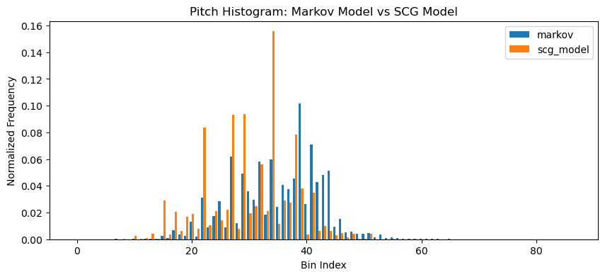

[figure not shown]

[figure not shown]

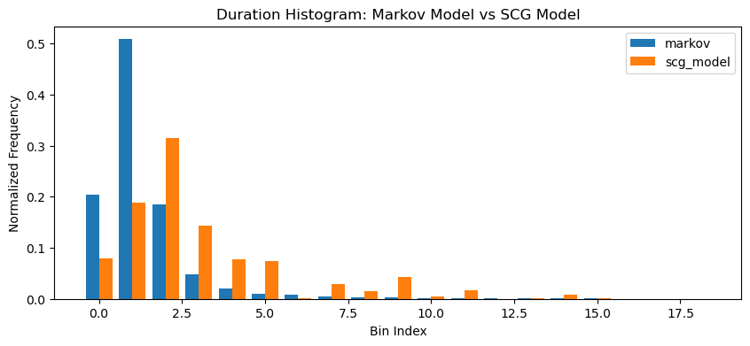

```
Train Beat STD Mean: 0.0000
markov Beat STD Mean: 0.0000
scg_model Beat STD Mean: 0.0000
markov Self-BLEU (diversity): 0.9783
Model2 Self-BLEU (diversity): 0.8841
Train Tempo STD Mean: 0.0000
Model1 Tempo STD Mean: 0.0000
Model2 Tempo STD Mean: 0.0000
```

```python
# ===== Parse notes from left hand (track 1) only =====

def parse_lh_notes_pretty_midi(midi_file):
    """
    Extract notes only from second instrument (track 1) - assumed left hand.
    Returns list of (pitch, duration) tuples.
    """
    pm = pretty_midi.PrettyMIDI(midi_file)
    if len(pm.instruments) <= 1:
        return []
    lh_instrument = pm.instruments[1]
    notes = []
    for note in lh_instrument.notes:
        duration = note.end - note.start
        notes.append((note.pitch, duration))
    return notes

# For model-generated samples, assume same parsing (left hand only)
parse_model_notes = parse_lh_notes_pretty_midi

train_folder = "data_left_hand/"
markov_folder = "generated_lh_by_rh/"
scg_model_folder = "symbolic_conditional/"

train_midis = get_midi_files_from_folder(train_folder)
markov_midis = get_midi_files_from_folder(markov_folder)
su_midis = get_midi_files_from_folder(scg_model_folder)

# Aggregate notes (only left hand for train, left hand for models)
train_notes = aggregate_notes_from_midis(train_midis, parse_lh_notes_pretty_midi)
markov_notes = aggregate_notes_from_midis(markov_midis, parse_model_notes)
scg_model_notes = aggregate_notes_from_midis(su_midis, parse_model_notes)

# Compute histograms
pitch_bins = range(21, 109)
duration_bins = np.linspace(0, 2.0, 20)

train_pitch_hist = get_pitch_histogram(train_notes, bins=pitch_bins)
markov_pitch_hist = get_pitch_histogram(markov_notes, bins=pitch_bins)
scg_model_pitch_hist = get_pitch_histogram(scg_model_notes, bins=pitch_bins)

train_duration_hist = get_duration_histogram(train_notes, bins=duration_bins)
markov_duration_hist = get_duration_histogram(markov_notes, bins=duration_bins)
scg_model_duration_hist = get_duration_histogram(scg_model_notes, bins=duration_bins)

# Plot pitch histograms: model vs train
plot_histograms(markov_pitch_hist, train_pitch_hist, 'markov', 'Train', 'Pitch Histogram: Markov Model vs Train')
plot_histograms(scg_model_pitch_hist, train_pitch_hist, 'scg_model', 'Train', 'Pitch Histogram: SCG Model vs Train')
plot_histograms(markov_pitch_hist, scg_model_pitch_hist, 'markov', 'scg_model', 'Pitch Histogram: Markov Model vs SCG Model')

# Plot duration histograms similarly
plot_histograms(markov_duration_hist, train_duration_hist, 'markov', 'Train', 'Duration Histogram: Markov Model vs Train')
plot_histograms(scg_model_duration_hist, train_duration_hist, 'scg_model', 'Train', 'Duration Histogram: SCG Model vs Train')
plot_histograms(markov_duration_hist, scg_model_duration_hist, 'markov', 'scg_model', 'Duration Histogram: Markov Model vs SCG Model')

# Compute Self-BLEU on pitch sequences
markov_sequences = get_pitch_sequences(markov_midis, parse_model_notes)
scg_model_sequences = get_pitch_sequences(su_midis, parse_model_notes)

markov_self_bleu = self_bleu(markov_sequences)
scg_model_self_bleu = self_bleu(scg_model_sequences)

train_beat_mean, train_beat_std = aggregate_beat_std(train_midis)
markov_beat_mean, markov_beat_std = aggregate_beat_std(markov_midis)
scg_model_beat_mean, scg_model_beat_std = aggregate_beat_std(su_midis)

print(f"Train Beat STD Mean: {train_beat_mean:.4f}")
print(f"markov Beat STD Mean: {markov_beat_mean:.4f}")
print(f"scg_model Beat STD Mean: {scg_model_beat_mean:.4f}")

print(f"markov Self-BLEU (diversity): {markov_self_bleu:.4f}")
print(f"Model2 Self-BLEU (diversity): {scg_model_self_bleu:.4f}")

train_tempo_mean, train_tempo_std = aggregate_tempo_stds(train_midis)
model1_tempo_mean, model1_tempo_std = aggregate_tempo_stds(markov_midis)
model2_tempo_mean, model2_tempo_std = aggregate_tempo_stds(su_midis)

print(f"Train Tempo STD Mean: {train_tempo_mean:.4f}")
print(f"Model1 Tempo STD Mean: {model1_tempo_mean:.4f}")
print(f"Model2 Tempo STD Mean: {model2_tempo_mean:.4f}")
```

## Generated Samples

### Task 1: Symbolic Unconditional Generation

[interactive chart not shown]

### Task 2: Symbolic Conditional Generation

[interactive chart not shown]